# Extra Credit - Generative Art

Author

Nicholas Vietto

# Getting Started

1.) [Head to Posit Cloud](https://posit.cloud/)

2.) Click “Get Started”

3.) Under “Cloud Free” click Learn more

4.) Click Sign Up then fill out the form

5.) Verify your email

6.) Once your in the posit Cloud, click “New Project”

[figure not shown]

7.) Then “New RStudio Project”

[figure not shown]

# Install and Load Libraries

*Write in each line below into the console then hit enter*

**You have to write these in, you can’t copy and paste these.**

[figure not shown]

install.packages(“aRtsy”)

*Each install will take time to run, so wait until the red stop sign in the corner disappears*

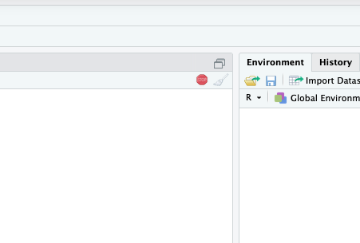

# Load the packages

*Once you finish installing, copy and paste this code below into the console and hit enter*

```r
library(aRtsy)
```

# Here is the fun part

Pick any one of the code chunks below (i.e., **Collatz conjecture**, **Fractal flames**, or **Rainbow smoke**), copy and paste it into the console.

**Tip**

You can simply edit the value inside the set.seed(this number here) and hit enter. Although there are other options to. Feel free to explore.

**Collatz conjecture**

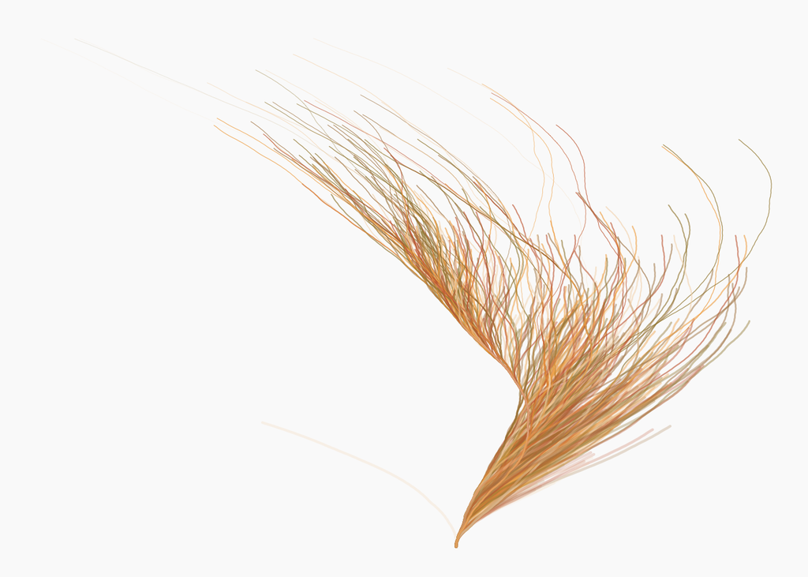

```r
set.seed(1)  # place any number between the ( )
canvas_collatz(colors = colorPalette("tuscany3"),
               n = 700, # a positive integer, adds more density or lines, computational dependent though (keep under 1000)
               side = FALSE) # If this is true it will flip to side
```

**Fractal flames**

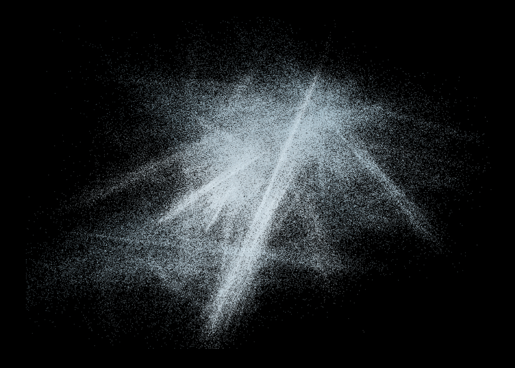

```r
set.seed(1)      # place any number between the ( )
canvas_flame(colors = colorPalette("dark2"),
             iterations = 1000000,   # Using more iterations results in images of higher quality but also increases the computation time
             symmetry = 0,
              blend = TRUE,
             resolution = 1000,  #  resolution of the artwork in pixels per row/column
             gamma = 5  # Larger values here make the image brighter
             )
```

**Rainbow smoke**

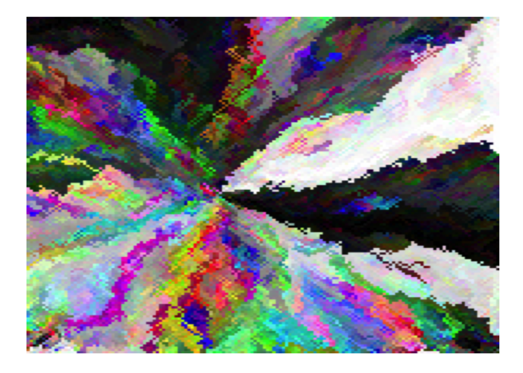

```r
set.seed(1)    # place any number between the ( )
canvas_smoke(colors = colorPalette("random", 1024),
             init = 1,
             resolution = 150, # Increasing this, increases the quality of the artwork but also increases the computation time
             shape = "cloud"  # can also try "smoke"
             )
```

# Submit

Once you have created your artwork, submit it on canvas. The best artwork will have it posted as an annocement so the entire class can see.

[figure not shown]

# References and Futher Reading

[aRtsy: Generative Art with R and ggplot2](https://cran.r-project.org/web/packages/aRtsy/readme/README.html)